# Reproduable Research: Project 1

Nabil Azamy

April 19, 2015

### Loading and preprocessing the data

```r
library(knitr)
library(ggplot2)
library(lattice)
data <- read.csv("activity.csv")
```

### Question No.1: What is mean total number of steps taken per day?

To calculate the number of steps taken per day the following was done to collect the aggregate number of steps:

```r
agg_steps <- aggregate(steps ~ date, data, sum, na.rm = TRUE)
```

and the following code produced a histogram demonstrating the steps taken per day:

```
## stat_bin: binwidth defaulted to range/30. Use 'binwidth = x' to adjust this.
```

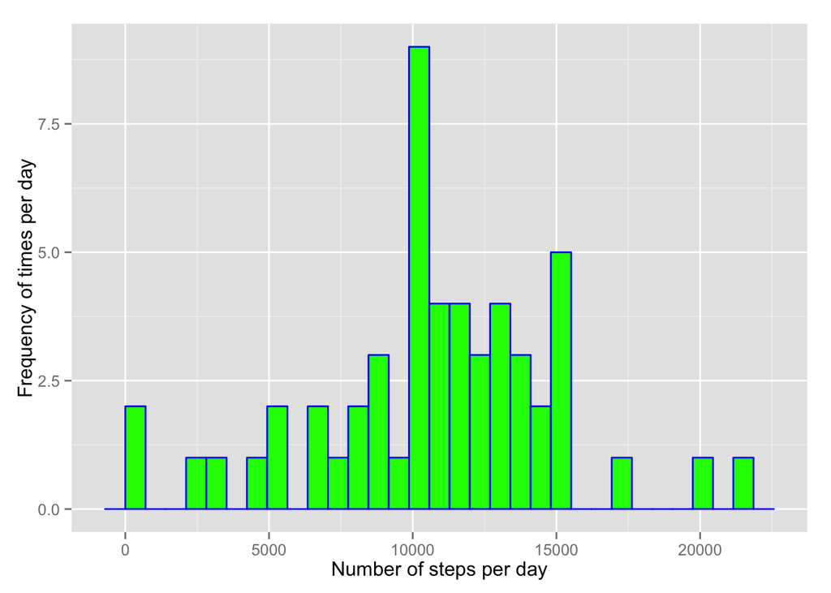

```r
ggplot(agg_steps, aes(steps)) + geom_histogram(colour = "blue", fill = "green") +
    labs( x = "Number of steps per day", y = "Frequency of times per day" )
```

with their mean and median being (respectively):

```
## [1] 10766.19
```

```
## [1] 10765
```

### Question No.2: What is the average daily activity pattern?

To determine the daily activity pattern an aggregate based on intervals was collected:

```r
agg_pattern <- aggregate(data$steps, by = list(data$interval), FUN = mean, na.rm = TRUE)
colnames(agg_pattern) <- c("interval", "steps")
```

and the resulting interval aggregate was plotted:

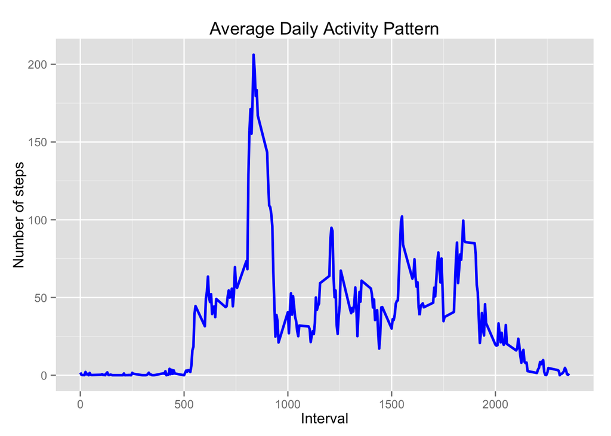

```r
ggplot(agg_pattern, aes(x=interval, y=steps)) + geom_line(color="blue", size=1) +
    labs(title="Average Daily Activity Pattern", x="Interval", y="Number of steps")
```

Determining the maximum step interval present in the data set:

```r
maximum_interval_step <- agg_pattern[which.max(agg_pattern$steps),]
```

```r
maximum_interval_step
```

```
##     interval    steps
## 104      835 206.1698
```

### Question No. 3: Inputing missing values:

The missing values in the original date set were determinied by the following:

```r
missing_values <- sum(!complete.cases(data))
```

and determined to be: 2304

To replace the NA values with one reflective of the data set the average values for each interval were used to fill in the NA values in the data set and again aggrigated as before:

```r
replace_na <- function(data, val)
    {
        na_index <- which(is.na(data$steps))
        na_replace <- unlist(lapply(na_index, FUN=function(idx)
            {
                interval = data[idx,]$interval
                val[val$interval == interval,]$steps
            }))
        fill_steps <- data$steps
        fill_steps[na_index] <- na_replace
        fill_steps
    }
replaced_values <- data.frame(steps = replace_na(data, agg_pattern),
                              date = data$date,interval = data$interval)
agg_steps_replaced <- aggregate(steps ~ date, replaced_values, sum, na.rm = FALSE)
```

To see if there were any remaining NA values in the dataset the following code was run again:

```r
missing_values_2 <- sum(!complete.cases(agg_steps_replaced))
```

and determined to be: 0

These aggregated values were again plotted to produce the following:

```
## stat_bin: binwidth defaulted to range/30. Use 'binwidth = x' to adjust this.
```

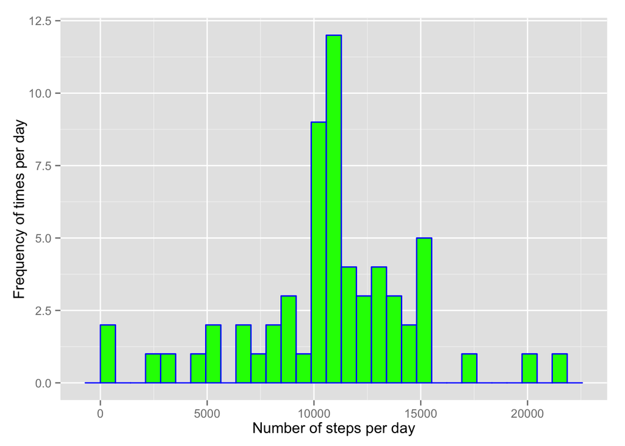

```r
ggplot(agg_steps_replaced, aes(x = steps)) + geom_histogram(colour = "blue", fill = "green") + labs( x = "Number of steps per day", y = "Frequency of times per day" )
```

Furthermore, to determine the difference between the original NA dataset and the newly created replaced NA dataset their mean and median differences were calculated:

```r
Mean_steps_replaced <- mean(agg_steps_replaced$steps)
Median_steps_replaced <- median(agg_steps_replaced$steps)

Mean_differences <- abs(Mean_steps_replaced - Mean_steps)
Median_differences <- abs(Median_steps_replaced - Median_steps)
```

Their mean difference: 0

and median difference: 1.1886792

### Question No. 4: Are there differences in activity patterns between weekdays and weekends?

To determine the difference in steps between weekdays and weekends the following was incorporated into the replaced value dataset:

```r
weekdays <- c("Monday", "Tuesday", "Wednesday", "Thursday",
              "Friday")
replaced_values$dow = as.factor(ifelse(is.element(weekdays(as.Date(replaced_values$date)),weekdays), "Weekday", "Weekend"))
```

An aggregate was produced to similar to before:

```r
steps_interval_date <- aggregate(steps ~ interval + dow, replaced_values, mean)
```

The resulting aggregate was plotted using the lattice package to plot both weekend and weekday interval differences:

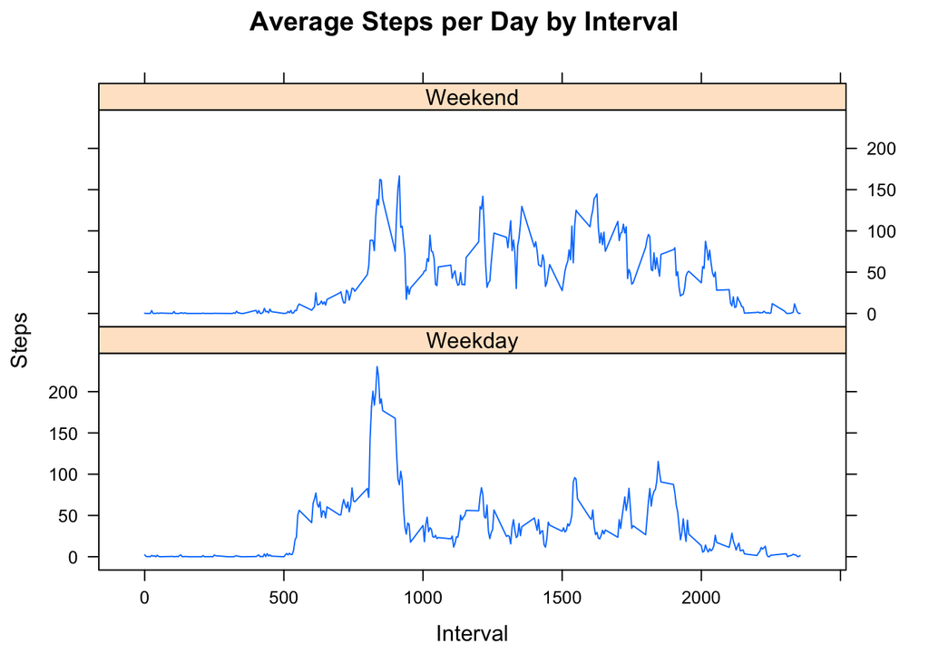

```r
xyplot(steps_interval_date$steps ~ steps_interval_date$interval|steps_interval_date$dow,main="Average Steps per Day by Interval",xlab="Interval", ylab="Steps",layout=c(1,2), type="l")
```

There is a greater degree of variation within the weekend dataset with the weekday set having a strong peak just shy of the 1000 interval mark, possibly suggesting a work commute or regular singularly weekely activity at that time.